# BFAR_generator.R

macair

Tue May 1 10:32:50 2018

### Introduction

Under the project “Effects of low population density on reef fish connectivity,” we conducted fieldwork and collected anemonefish samples in Leyte from 2018-03-03 to 2018-04-10. The primary objective was to collect tissue samples (fin clips) from individuals of Amphiprion clarkii at each of 14 locations. In this season, we sampled 14 sites in Albuera and Bay Bay City, Leyte.

We are now conducting laboratory analysis of the collected specimens. We are using genotyping-by-sequencing methods to genotype each specimen at a number of Single Nucleotide Polymorphisms (SNPs). This will allow us to match parents and offspring and to identify when we recapture the same fish in a different field season. This information will allow us to determine whether small populations are self-persistent or whether they rely on surrounding populations for persistence (network persistence).

### Inventory

Note: All samples are tissue clips from the caudal fin.

```r
knitr::kable(bfar)
```

| Site_number | Province | Municipality | Site | Samples |
| --- | --- | --- | --- | --- |
| 1 | Leyte | Albuera | Cabatoan | 18 |
| 2 | Leyte | Baybay | Elementary School | 9 |
| 3 | Leyte | Baybay | Haina | 21 |
| 4 | Leyte | BayBay | Haina | 70 |
| 5 | Leyte | Baybay | Hicgop South | 11 |
| 6 | Leyte | Albuera | Magbangon | 30 |
| 7 | Leyte | Albuera | Palanas | 80 |
| 8 | Leyte | Baybay | Poroc Rose | 7 |
| 9 | Leyte | Baybay | Poroc San Flower | 1 |
| 10 | Leyte | Baybay | San Agustin | 12 |
| 11 | Leyte | Baybay | Sitio Baybayon | 248 |
| 12 | Leyte | Baybay | Tamakin Dacot | 46 |
| 13 | Leyte | Baybay | Visca | 13 |
| 14 | Leyte | Albuera | Wangag | 170 |

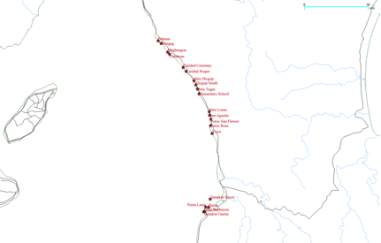

```r
map_path <- "/Users/macair/Documents/field/data/leyte_map.png"
knitr::include_graphics(map_path)
```